# US Census: Savings prediction

Molina Rafidison

June 15, 2016

# Introduction

## Introduction

This analysis aims to identify which people in the test dataset won more or less than $50,000 per year.

## Preliminaries

### Reproducibility

Set the following seed to make sure the analysis is reproducible.

```r
seed <- 201606
```

Load the needed packages and install them if `FALSE`.

```r
packages <- c("ggplot2", "tabplot", "caret", "plyr", "dplyr")
sapply(packages, require, character.only = TRUE, quietly = TRUE)
```

```
## ggplot2 tabplot   caret    plyr   dplyr
##    TRUE    TRUE    TRUE    TRUE    TRUE
```

### Getting and reading data

Download [the Internet-based file](http://thomasdata.s3.amazonaws.com/ds/us_census_full.zip) and read data.

```r
## Set path
path <- getwd()

## Download directory
if (!file.exists("us_census_full")) {
    fileUrl <- "http://thomasdata.s3.amazonaws.com/ds/us_census_full.zip"
    tempFile <- "Dataset.zip"
    download.file(fileUrl, file.path(path, tempFile))
    ## Unzipping
    unzip(file.path(path, tempFile))
    ## Deleting temporary compressed file
    unlink(tempFile)
}

## Read data
train <- read.csv(file.path(path, "us_census_full/census_income_learn.csv"),
                  na.strings = c("NA", "#DIV/0!", ""))
test <- read.csv(file.path(path, "us_census_full/census_income_test.csv"),
                 na.strings = c("NA", "#DIV/0!", ""))
info <- read.csv(file.path(path, "us_census_full/census_income_metadata.txt"),
                 header = FALSE)
```

Get an idea of the datasets dimensions.

```r
dim(train); dim(test)
```

```
## [1] 199522     42
```

```
## [1] 99761    42
```

### Rename variables

The variables names are all messed up. I would like them to match the ones we can read on the text files. This will simplify the exploration and manipulation later on.

```r
varName <- gsub("[\\(\\)]", "", regmatches(info[89:128, ], gregexpr("\\(.*?\\)", info[89:128, ])))
varName <- gsub(" ", "\\.", varName)

replaceName <- function(data) {
    dataName <- names(data)
    dataName[25] <- "instance.weight"
    dataName[42] <- "incomes"
    dataName[-c(25, 42)] <- varName
    return(dataName)
}

names(train) <- replaceName(train); names(test) <- replaceName(test)
```

### Adding missing values

We have some `?` and `Not in universe` in the data. In my context, I will just replace them with NAs and work on them if need be along with the analysis.

```r
misVal <- function(data) {
    dataList <- lapply(data, function(x) {gsub("\\?|Not in universe *.*", NA, x)})
    data <- as.data.frame(dataList)
    return(data)
}

train <- misVal(train); test <- misVal(test)
```

## Reviewing classes

Because of the previous change, I need to rewrite some of the variables’ class.

```r
contiVar <- c(1, 6, 17, 18, 19, 31, 40)
train[, contiVar] <- apply(train[, contiVar], 2, function(x) {as.integer(as.character(x))})
test[, contiVar] <- apply(test[, contiVar], 2, function(x) {as.integer(as.character(x))})
```

### Basic summary

Here we go with this data:

```r
summary(train)
```

```
##       age                               class.of.worker
##  Min.   : 0.00    Private                       : 72028
##  1st Qu.:15.00    Self-employed-not incorporated:  8445
##  Median :33.00    Local government              :  7784
##  Mean   :34.49    State government              :  4227
##  3rd Qu.:50.00    Self-employed-incorporated    :  3265
##  Max.   :90.00   (Other)                        :  3529
##                  NA's                           :100244
##  detailed.industry.recode detailed.occupation.recode
##  0      :100683           0      :100683
##  33     : 17070           2      :  8756
##  43     :  8283           26     :  7887
##  4      :  5984           19     :  5413
##  42     :  4683           29     :  5105
##  45     :  4482           36     :  4145
##  (Other): 58337           (Other): 67533
##                        education     wage.per.hour
##   High school graduate      :48406   Min.   :   0.00
##   Children                  :47422   1st Qu.:   0.00
##   Some college but no degree:27820   Median :   0.00
##   Bachelors degree(BA AB BS):19865   Mean   :  55.43
##   7th and 8th grade         : 8007   3rd Qu.:   0.00
##   10th grade                : 7557   Max.   :9999.00
##  (Other)                    :40445
##           enroll.in.edu.inst.last.wk
##   College or university:  5688
##   High school          :  6892
##  NA's                  :186942
##
##
##
##
##                            marital.stat
##   Divorced                       :12710
##   Married-A F spouse present     :  665
##   Married-civilian spouse present:84222
##   Married-spouse absent          : 1518
##   Never married                  :86485
##   Separated                      : 3460
##   Widowed                        :10462
```

[output cut: 145 more lines]

```
##  0:180671                       No :  1593
##  1:  2698                       Yes:   391
##  2: 16153                      NA's:197538
##
##
##
##
##  veterans.benefits weeks.worked.in.year year            incomes
##  0: 47409          Min.   : 0.00        94:99827    - 50000.:187140
##  1:  1984          1st Qu.: 0.00        95:99695    50000+. : 12382
##  2:150129          Median : 8.00
##                    Mean   :23.18
##                    3rd Qu.:52.00
##                    Max.   :52.00
##
```

# Cleaning data

## Engineering features

For the purpose of this exercise and given the short timeframe, we will work only on a few variables. The analysis could be more thorough with further feature engineering though. I also have to think that the following manipulations will have to appear on the test dataset too to properly train my models.

### Main outcome

The outcome `incomes` is a factor with two levels. Let’s clean up its levels.

```r
cleanIncome <- function(curVar) {
    sapply(curVar, function(x) {
        if (x == " 50000+.") {
            curVar <- "50k+"
        } else {
            curVar <- "-50k"
        }
    })
}

train$incomes <- cleanIncome(train$incomes)
train$incomes <- factor(train$incomes)

test$incomes <- cleanIncome(test$incomes)
test$incomes <- factor(test$incomes)
```

### Slicing ages

Let’s look at the `age` variable.

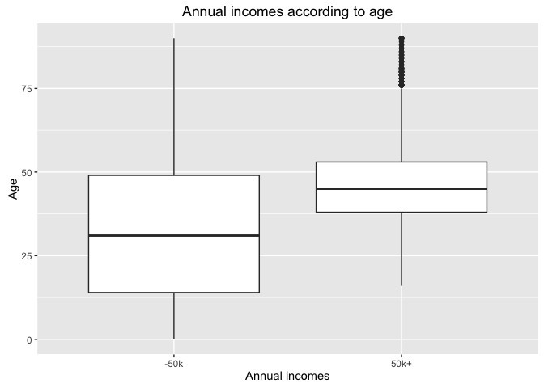

```r
ggplot(train, aes(x = incomes, y = age, group = incomes)) +
    geom_boxplot() +
    labs(title = "Annual incomes according to age",
         x = "Annual incomes",
         y = "Age")
```

I create five levels to convert the `age` variable into a factor.

```r
sliceAge <- function(curVar, newVar) {
    sapply(curVar, function(x) {
        if (x < 16) {
            newVar <- "Child"
        } else if (x %in% 16:33) {
            newVar <- "Young adult"
        } else if (x %in% 34:52) {
            newVar <- "Adult"
        } else if (x %in% 53:64) {
            newVar <- "Senior adult"
        } else {
            newVar <- "Oldest"
        }
    })
}

train$ageType <- factor(sliceAge(train$age, train$ageType))
test$ageType <- factor(sliceAge(test$age, test$ageType))
```

### Giving degrees

Let’s see how education impact the incomes.

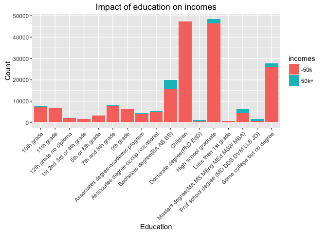

```r
ggplot(train, aes(x = education, fill = incomes)) +
    geom_bar() +
    theme(axis.text.x = element_text(angle = 45, hjust = 1)) +
    xlab("Education") +
    ylab("Count") +
    ggtitle("Impact of education on incomes")
```

It might be interesting to create a variable that tells whether a person has a degree or not while keeping those who went to college and got no degree.

```r
sortDegree <- function(curVar, newVar) {
    noDegree <- levels(train$education)[c(1:7, 11, 14)]
    degree <- levels(curVar)[c(8:10, 12, 13, 15, 16)]
    sapply(curVar, function(x) {
        if (x %in% noDegree) {
            newVar <- "No degree"
        } else if (x %in% degree) {
            newVar <- "Degree"
        } else {
            newVar <- "College no degree"
        }
    })
}

train$degree <- factor(sortDegree(train$education, train$degree))
test$degree <- factor(sortDegree(test$education, test$degree))
```

### Identifying workers

The class of worker is interesting and could be more complete with an additional level for non-working people.

```r
levels(train$class.of.worker) <- c(levels(train$class.of.worker), "Non worker")
levels(test$class.of.worker) <- c(levels(test$class.of.worker), "Non worker")

train$class.of.worker[is.na(train$class.of.worker)] <- "Non worker"
test$class.of.worker[is.na(test$class.of.worker)] <- "Non worker"
```

On the other hand, being enrolled in education at that time can also impact the incomes. Let’s create a `Student` variable.

```r
train$isStudent[is.na(train$enroll.in.edu.inst.last.wk)] <- "Non post-graduate student"
train$isStudent[!is.na(train$enroll.in.edu.inst.last.wk)] <- "Post-graduate student"
train$isStudent <- factor(train$isStudent)

test$isStudent[is.na(test$enroll.in.edu.inst.last.wk)] <- "Non post-graduate student"
test$isStudent[!is.na(test$enroll.in.edu.inst.last.wk)] <- "Post-graduate student"
test$isStudent <- factor(test$isStudent)
```

Now we differentiate levels based on the `Wage per hour` variable.

```r
sliceWage <- function(curVar, newVar) {
    sapply(curVar, function(x) {
        if (x < 20) {
            newVar <- "Nothing"
        } else if (x %in% 20:585) {
            newVar <- "20 to 585"
        } else if (x %in% 586:800) {
            newVar <- "586 to 800"
        } else if (x %in% 801:1200) {
            newVar <- "801 to 1200"
        } else {
            newVar <- "1201+"
        }
    })
}

train$wageClass <- factor(sliceWage(train$wage.per.hour, train$wageClass))
test$wageClass <- factor(sliceWage(test$wage.per.hour, test$wageClass))
```

And I finally convert the number of weeks worked in a year into a factor.

```r
train$weeks.worked.in.year <- factor(train$weeks.worked.in.year)
test$weeks.worked.in.year <- factor(test$weeks.worked.in.year)
```

### Counting gains

There are three variables that could strongly impact the income that are the different sources of gains or losses. To get a general idea of a person’s status, I take the capital gains or losses and dividends to compute to know whether the trend is positive or negative.

```r
train$extGains <- train$capital.gains - train$capital.losses + train$dividends.from.stocks
test$extGains <- test$capital.gains - test$capital.losses + test$dividends.from.stocks

compGains <- cleanIncome <- function(curVar) {
    sapply(curVar, function(x) {
        if (x == 0) {
            curVar <- "Null"
        } else if (x > 0) {
            curVar <- "Positive"
        } else {
            curVar <- "Negative"
        }
    })
}

train$extGains <- factor(compGains(train$extGains))
test$extGains <- factor(compGains(test$extGains))
```

### Looking at householders

I graph a barplot to observe any pattern with regards of the households details.

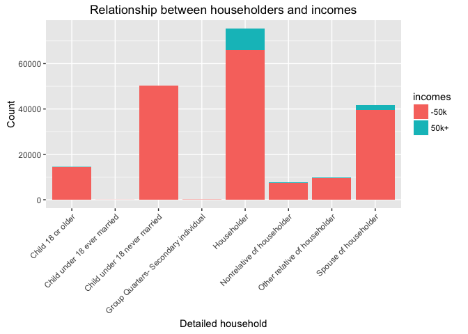

```r
ggplot(train, aes(x = detailed.household.summary.in.household, fill = incomes)) +
    geom_bar() +
    theme(axis.text.x = element_text(angle = 45, hjust = 1)) +
    xlab("Detailed household") +
    ylab("Count") +
    ggtitle("Relationship between householders and incomes")
```

Spotting householders or householders’ spouses seem to be a good point to help us predict the income. I just would llike to modify the variable’s name, which is long at the moment.

```r
names(train)[24] <- "householdSummary"
names(test)[24] <- "householdSummary"
```

## Observations

Once again, given the short timeframe, I had to make choices and decided not to go further with the feature engineering. Yet there are many things I would have study and here below is an overview.

### Annual income

I noticed that around half of the training dataset is based on 1994 and the other half on 1995. We could think that they are potentially the same population whose data were collected on these two consecutive years.

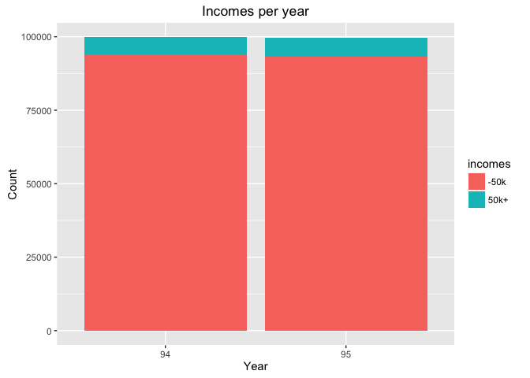

```r
ggplot(train, aes(x = year, fill = incomes)) +
    geom_bar() +
    xlab("Year") +
    ylab("Count") +
    ggtitle("Incomes per year")
```

### Focus on migration

The data focuses a lot on the migration aspect. I noticed that some people who were born in specific countries (out of the USA) are more likely to have a 50k+ income like Hungary, Jamaica or Trinidad & Tobago.

### Closer relationships

There are many information crossed in multiple variables. I am quite sure that mixing some other variables could have been interesting to be even more accurate - people who have children, the number of children per household, where they live based on the migration code, and so on…

### Missing values

I replaced the “Not in universe” values with NAs but both are different. “Not in universe” means that the respondant was not concerned by the question asked. I could have study the real NAs and see whether it would have been relevant to impute the missing values.